# ¿Por qué explorar y lidiar con valores faltantes?

Para responderla imaginemos un caso.

**¿Existe una brecha salarial entre hombres y mujeres?**, es decir una pregunta cerrada. También podríamos continuar diciendo, si existe ¿qué tan grande es la brecha?

Para esto logramos estratificar personas que me ayuden a responder esta pregunta

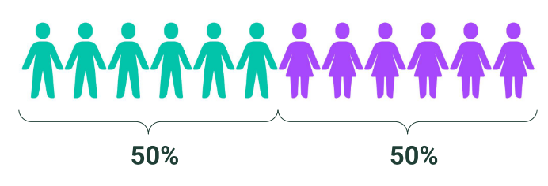

Es decir 50% hombres y 50% mujeres, les aplicamos la encuesta para saber su salario. Y vaciamos todo en un formato de tabla teniendo lo siguiente:

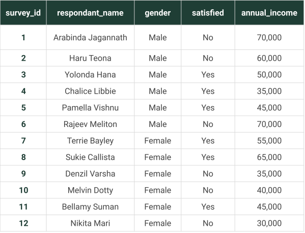

Dado que tenemos todos los datos, le podemos aplicar una análisis y así saber cual es en promedio el salario de hombres y mujeres:

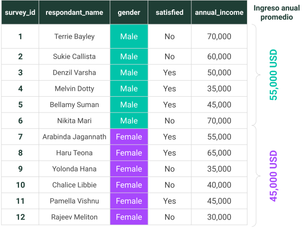

Vemos los resultados y entonces podríamos deducir que **SÍ, EXISTE UNA BRECHA SALARIAL Y LOS HOMBRES GANAN MÁS QUE LAS MUJERES**. Pero ¿qué pasa y por qué esto podría ser importante en el contexto de los valores faltantes?

Porque van a salir preguntas sobre:

#### ¿Qué podría pasar si **llegan a faltar valores**?

Para esto imaginemos la siguiente tabla:

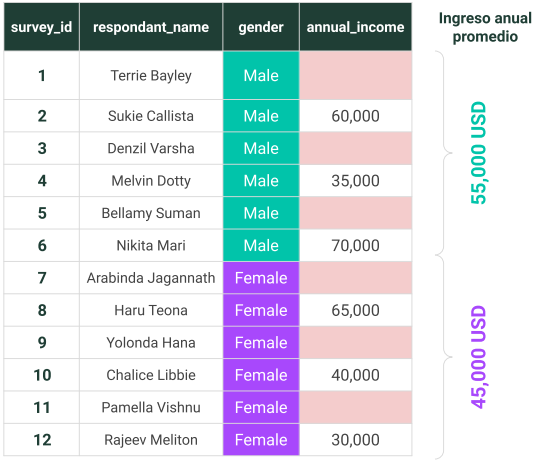

Ahora algunos valores han desaparecido, algo paso aquí y entonces volvamos a calcular el promedio con los mismos valores. El resultado que nos arroja es que no cambio nada

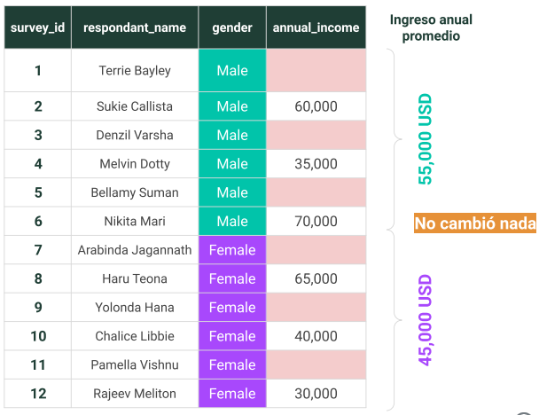

A pesar de que nos faltan valores en esta tabla, de ciertas personas que no quisieron contestar esta encuesta, nuestro promedio se mantuvo y probablemente estos valores se perdieron al azar y digamos que no tiene nada que ver con otras cosas.

#### Pero ¿si hubieran sido otros valores los que faltan?

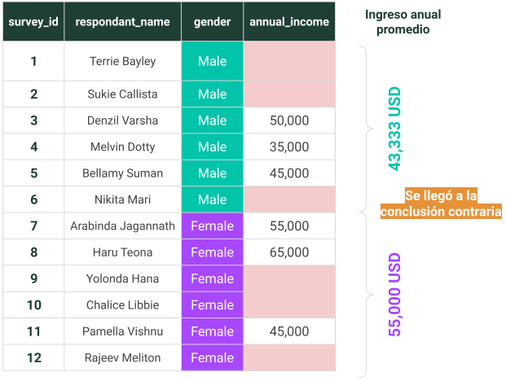

Calculando nuevamente el promedio nos damos cuenta que las mujeres están percibiendo más que los hombres y hemos llegado a la conclusión contraria de mi primer caso. Esto es interesante porque el hecho de que nos falten observaciones o registros, modifica totalmente el resultado a lo que nos mostraba nuestros datos en un comienzo.

## ¿Se puede explicar la **ausencia de los valores faltantes**?

Se puede explicar o +por qué esto esta sucediendo? es decir como es que hemos llegado a esta conclusión contraria. Ahora recordemos que hay una pregunta ¿estas satisfecho con tu salario? y este promedio sale de ahí.

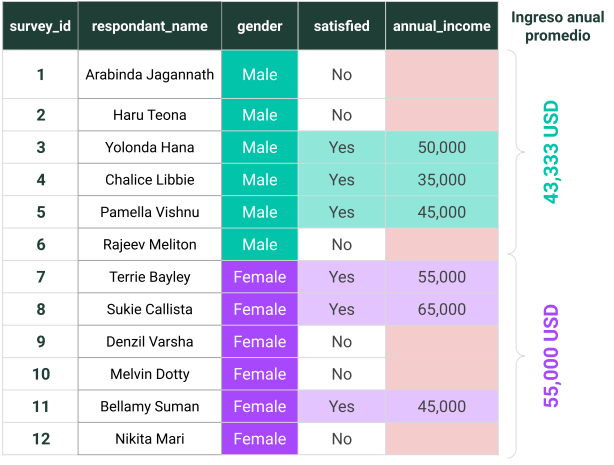

Esto está ligado completamente con el resultado, es decir podemos afirmar que el resultado del promedio salarial de las mujeres es mayor dentro de la categoría **estoy satisfecho con mi salario** y es decir no afecta a toda la muestra de nuestra encuesta.

## ¿Y si las personas que respondieron fueron las que no estaban satisfechas con su salario?

En este caso volvemos a calcular el promedio salarial y obtenemos lo siguiente:

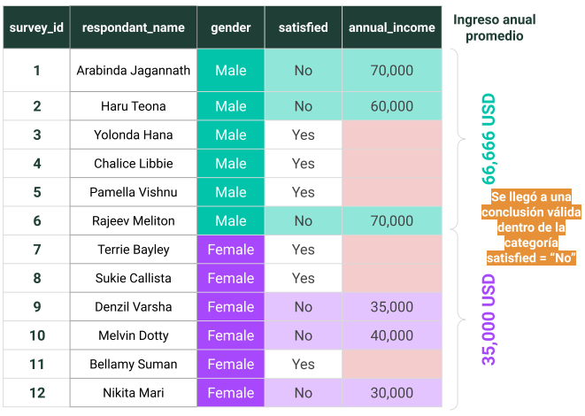

En este caso obtenemos que los hombres ganan en promedio más, pero vemos que la brecha salarial aumento y podemos decir que esto nuevamente solo es valido en la categoría **no estoy satisfecho con mi salario**.

Entonces ya podemos darnos cuenta de ciertas peculiaridades al trabajar con valores faltantes y cómo estos pueden alterar el flujo de trabajo y mis resultados.

También podríamos preguntarnos

## ¿Y si mis valores faltantes tuvieran un comportamiento mucho más complejo?

¿Por qué debería explorar y lidiar con los valores faltantes?

Entonces aquí vamos a concluir que si por alguna extraña razón ignoramos estos valores faltantes, estamos introduciendo sesgos en los análisis y en los modelos. Es decir mi valor real lo puedo **Sobre-estimar o Sub-estimar**.

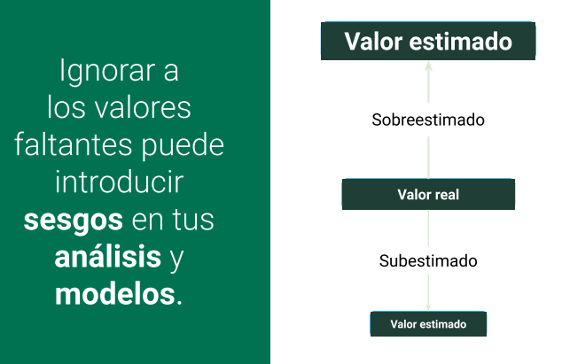

Llegando a conclusiones que tal vez no sean correctas, además por alguna razón **múltiples algoritmos fallarán**.

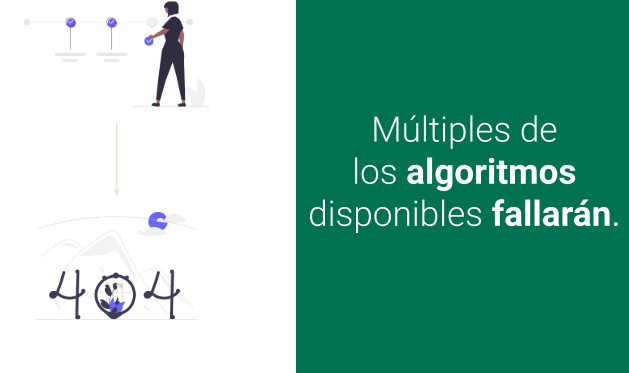

Debido a que los algoritmos disponibles para los modelos no aceptan valores faltantes.

Por eso recuerda esta frase:

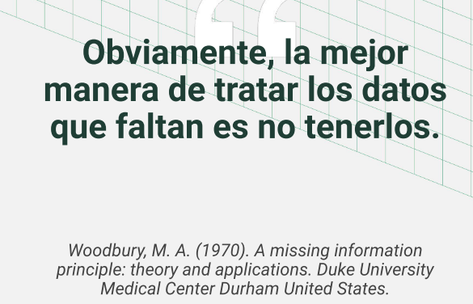

Pero en la realidad no es así, porque siempre o muy a menudo habrán valores faltantes, por eso necesitamos aprender como explorarlos y cómo tratarlos. Este curso trata justamente de eso.